# Homework #2

### Directions

For this assignment you should record your answers in an R Markdown file and submit the compiled output (either as an html file in a zipped folder, a pdf, or a word document).

*Homework #2 is due Monday 9/19 by 11:59pm*

### Question #1

The data.frame `msleep` is contained within the `ggplot2` package. These data record the attributes of 83 different animals and information about their sleep patterns. For this question, your goal is to recreate the graph below as closely as possible. A few hints:

- Pay attention to the scales, theme, and labels
- A size of 3 is used for the text geoms
- The default colors are used

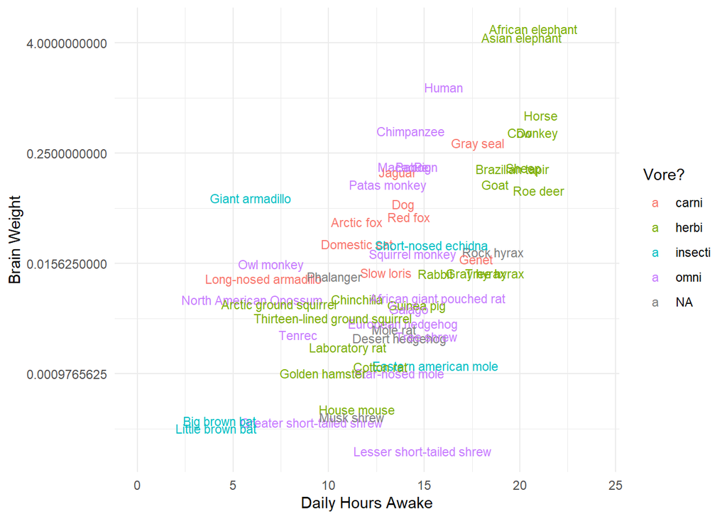

```r
library(ggplot2)  # Make sure you have this package installed
data("msleep") # Puts the "msleep" data frame in your environment
```

### Question #2 - Part A

The data.frame `economics` in the `ggplot2` package contains US economic data provided by [US federal reserve](https://fred.stlouisfed.org/).

For Part A of this question, write code that transforms the data from a wide format to a long format (see Part B for details on how the long formatted data will be used) where each row is an economic outcome (`pce`, `psavert`, `unemped`, `unemploy`) on a specific date. For simplicity, you may drop the variables not needed in Part B prior to reshaping the data.

```r
library(ggplot2)  # Make sure you have this package installed
data("economics") # Puts the "economics" data frame in your environment

## Add your code here
```

### Question #2 - Part B

Using the data frame you created in Part A, write code that uses `ggplot` to create a line graph which displays the variables `uempmed` and `psavert` on the y-axis and `date` on the x-axis. Use the `color` aesthetic to differentiate the lines of each variables.

In the space below your code, use your visual to briefly describe whether these variables appear to be related.

```r
## Add your code here
```

$~$

### Question #3

The data.frame `ChickWeight` in the `datasets` package contains data from an experiment studying the effects of different diets on the growth rate of chicks (young chickens).

In the code chunk below, write code that constructs a data.frame named “chick_df” that contains the *median weight* for each diet group *at each time-point* using the `group_by` and `summarize` functions in the `dplyr` package. (Hint: you can group by more than one variable in the `group_by` function)

Then, use `ggplot` to construct a line graph displaying the mean weight of each diet group over time. (Hint: You shouldn’t be using `geom_smooth` to make your plot, you should plot the means directly).

Below your code, briefly discuss what else you’d need to add to your plot to make a valid *statistical argument* that Diet #3 provides the best nutrition to chicks.

```r
library(datasets)  # Make sure you have this package installed
data("ChickWeight")

## Your code for question 3 goes here
```

$~$

### Question #4 - Part A

[Sean Lahman](https://en.wikipedia.org/wiki/Sean_Lahman) complied a comprehensive database containing pitching, hitting, and fielding statistics from all Major League Baseball games from 1871 through 2016. The database is available in the package `Lahman` and contains several tables.

- The data frame “People” contains one row per unique player for a 20,370 current and former MLB players.
- The data frame “Batting” contains player performance data for each season (year). It contains 110,495 observations, as most of the players in “People” have careers spanning several years.

```r
# install.packages("Lahman")
library(Lahman)
data("People")
data("Batting")
```

For Part A, use the “People” and “Batting” data frames to find a list of players in the 40/40 club. That is, find all unique players who have achieved 40 steals, “SB”, and 40 home runs, “HR” in the same season. Be sure that players who have achieved the 40/40 standard in multiple seasons only appear in your list once. Print the number of rows in your final data frame.

```r
## Your code for question 4-A goes here
```

### Question #4 - Part B

For Part B, using the `group_by()` and `summarize()` functions, find the total number of home runs for each player in the “Batting” data frame. Then, store the top 30 players (with the most career home runs) in a separate data frame.

```r
## Your code for question 4-B goes here
```

### Question #4 - Part C

It has been hypothesized that [an athlete’s birth month](https://fivethirtyeight.com/features/why-athletes-birthdays-affect-who-goes-pro-and-who-becomes-a-star/) is related to future success in sports.

For Part C, add birth month information from the “People” data frame to the new data frame you created in Part B (containing the top 30 home run hitters). Then, create a data visualization exploring whether birth months appear to be uniformly distributed among these players.

```r
## Your code for question 4-C goes here
```

$~$

### Question #5 - Part A

Twitter is a popular social media network in which users can send and receive short messages (called “tweets”) on any topic they wish. For this question you will analysis data contained in the file **Ghostbusters.txt** (which can be read using the code below). This file contains 5000 tweets downloaded from Twitter on July 18, 2016, based on a search of the word “ghostbusters”.

```r
## Because the format of twitter data is differently than what we're used to
## we'll need the "scan" function to read it into R. "scan" will search for particular
## characters and use them to define each element of the object it returns
data <- scan("https://raw.githubusercontent.com/ds4stats/case-studies/master/twitter-sentiment/Ghostbusters.txt", what = "")
```

```r
# Your code for 5-A here
```

### Question #5 - Part B

On twitter, a user may echo another user’s tweet to share it with their own followers by “retweeting”. In these data, all retweets begin with the letters “RT” followed by “@” and the original user’s twitter name. For this question, write code that stores retweets into a separate data set, then use the `length` function to find the number of tweets in this dataset.

```r
# Your code for 5-B here
```

### Question #5 - Part C

After excluding retweets, find the number of tweets where “hate” or “hated” (of any capitalization) appear, and the number of tweets where “love”, “loved”, or “looved” (and all variants with more “o”s or other capitalization) appear. *Hint*: the `sum()` function can be used to count the number of `TRUE` elements in a logical vector, which can be used in conjunction with `str_detect()` to answer this question.

```r
# Your code for 5-C here
```

**Side Remark**: To download tweets from Twitter, you need to have a Twitter account and then sign into the developer page. Analyzing twitter data makes for a potentially interesting project. Details on the authentication procedure can be found at this link: http://thinktostart.com/twitter-authentification-with-r/